# Estudio de la distribución de salarios

#### El análisis de la distribución salarial dentro de una organización permite identificar posibles diferencias entre grupos de trabajadores. En un primer examen de los datos de salarios de la universidad objeto de estudio, se observa que el salario promedio de los hombres es mayor que el de las mujeres. Sin embargo, este tipo de comparación agregada puede conducir a interpretaciones incompletas o incluso engañosas si no se consideran otras variables que influyen en la estructura salarial, como el tipo de cargo, la categoría académica o la antigüedad.

#### En este contexto resulta relevante considerar el fenómeno estadístico conocido como la Paradoja de Simpson, descrita inicialmente en trabajos asociados a Karl Pearson, según el cual una tendencia observada en datos agregados puede cambiar o desaparecer cuando los datos se analizan por subgrupos. Por esta razón, el presente trabajo propone realizar un desglose de la información salarial, con el fin de evaluar si la diferencia observada en los promedios generales se mantiene dentro de grupos comparables o si se explica por la distribución de hombres y mujeres en distintos tipos de cargos dentro de la universidad.

```python
# Librerías
import pandas as pd
import numpy as np
import matplotlib.pyplot as plt
import seaborn as sns
```

#### Una vez cargadas las librerías, se procede a cargar el conjunto de datos. Al hacer una primera visualización de la información se puede apreciar que los nombres de las columnas y los registros están en inglés. Además, existe la posibilidad de que hayan valores nulos, atípicos o incoherentes dentro del conjunto de datos. Para evitar errores en el análisis, se debe hacer primero un preprocesamiento de los datos. Esto es un procedimiento estándar en cualquier actividad que incluya el análisis de información estructurada.

```python
archivo = 'Salaries'
df = pd.read_excel(archivo + '.xlsx')
df.head()
```

|  | rank | discipline | yrs.since.phd | yrs.service | sex | salary |
| --- | --- | --- | --- | --- | --- | --- |
| 0 | Prof | B | 19.5 | 18 | Male | 139750 |
| 1 | Prof | B | 20.0 | 16 | Male | 173200 |
| 2 | AsstProf | B | 4.0 | 3 | Male | 79750 |
| 3 | Prof | B | 45.0 | 39 | Male | 115000 |
| 4 | Prof | B | 40.0 | 41 | Male | 141500 |

```python
df.info()
# Aquí nos damos cuenta que no hay datos nulos, sin embargo, es necesario hacer renombramientos
```

```
<class 'pandas.core.frame.DataFrame'>
RangeIndex: 397 entries, 0 to 396
Data columns (total 6 columns):
 #   Column         Non-Null Count  Dtype
---  ------         --------------  -----
 0   rank           397 non-null    object
 1   discipline     397 non-null    object
 2   yrs.since.phd  397 non-null    float64
 3   yrs.service    397 non-null    int64
 4   sex            397 non-null    object
 5   salary         397 non-null    int64
dtypes: float64(1), int64(2), object(3)
memory usage: 18.7+ KB
```

# 1. Preprocesamiento

## 1.1. Variables categóricas

```python
df.columns = ['Rango', 'Disciplina', 'Años_desde_Phd', 'Años_servicio', 'Sexo', 'Salario']
```

```python
df.select_dtypes('object').head(2)
```

|  | Rango | Disciplina | Sexo |
| --- | --- | --- | --- |
| 0 | Prof | B | Male |
| 1 | Prof | B | Male |

```python
df['Rango'].unique()
```

```
array(['Prof', 'AsstProf', 'AssocProf'], dtype=object)
```

```python
df.loc[df['Rango'] == 'Prof' , 'Rango'] = 'Profesor'
df.loc[df['Rango'] == 'AsstProf' , 'Rango'] = 'Asistente'
df.loc[df['Rango'] == 'AssocProf' , 'Rango'] = 'Asociado'
```

```python
df.loc[df['Sexo'] == 'Male' , 'Sexo'] = 'Hombre'
df.loc[df['Sexo'] == 'Female' , 'Sexo'] = 'Mujer'
```

## 1.2. Variables numéricas

```python
df.select_dtypes('number').head(2)
```

|  | Años_desde_Phd | Años_servicio | Salario |
| --- | --- | --- | --- |
| 0 | 19.5 | 18 | 139750 |
| 1 | 20.0 | 16 | 173200 |

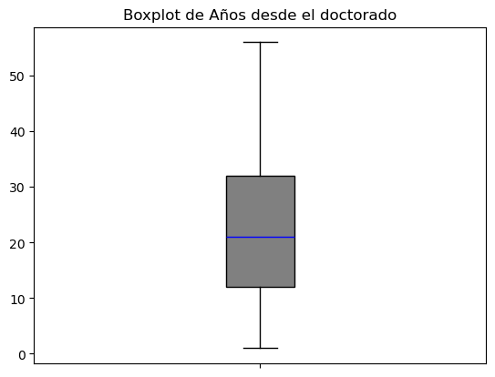

```python
df['Años_desde_Phd']
plt.boxplot(df['Años_desde_Phd'], patch_artist=True,
           boxprops=dict(facecolor='gray'),
           medianprops = dict(color='blue'),
            tick_labels = ['']
           )
plt.title('Boxplot de Años desde el doctorado')
plt.show()
```

#### La cantidad de años transcurridos desde el doctorado es relativamente uniforme, sin embargo, el 50% de los profesores más antiguos tienen mayor variación.

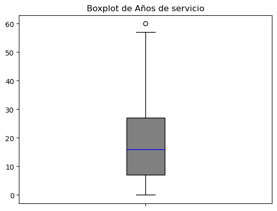

```python
df['Años_servicio']
plt.boxplot(df['Años_servicio'], patch_artist=True,
           boxprops=dict(facecolor='gray'),
           medianprops = dict(color='blue'),
            tick_labels = ['']
           )
plt.title('Boxplot de Años de servicio')
plt.show()
```

#### En esta distribución se puede observar que la mediana de los años es aproximadamente 15. Hay una mayor acumulación en la mitad de profesores contratados más reciente, en cambio, el otro 50% de los profesores presentan una distribución mayor, variando desde los 15 años hasta casi los 60, incluso uno de los docentes tiene 60 años de servicio en la universidad.

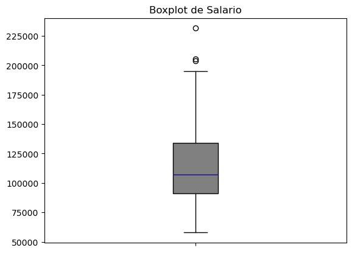

```python
df['Salario']
plt.boxplot(df['Salario'], patch_artist=True,
           boxprops=dict(facecolor='gray'),
           medianprops = dict(color='blue'),
            tick_labels = ['']
           )
plt.title('Boxplot de Salario')
plt.show()
```

```python
df.loc[df['Salario'] >= 200000 , ]
```

|  | Rango | Disciplina | Años_desde_Phd | Años_servicio | Sexo | Salario |
| --- | --- | --- | --- | --- | --- | --- |
| 43 | Profesor | B | 38.0 | 38 | Hombre | 231545 |
| 249 | Profesor | A | 29.0 | 7 | Hombre | 204000 |
| 364 | Profesor | A | 43.0 | 43 | Hombre | 205500 |

```python
df = df.loc[df['Salario'] < 200000 , ]
```

```python
df.loc[df['Años_servicio'] >= 55 , ]
```

|  | Rango | Disciplina | Años_desde_Phd | Años_servicio | Sexo | Salario |
| --- | --- | --- | --- | --- | --- | --- |
| 131 | Profesor | A | 56.0 | 57 | Hombre | 76840 |
| 330 | Profesor | B | 49.0 | 60 | Hombre | 192253 |

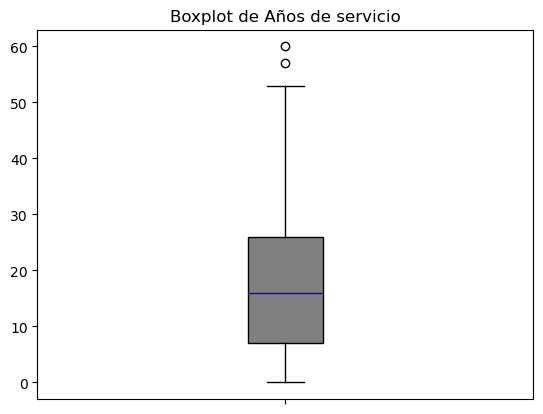

```python
df['Años_servicio']
plt.boxplot(df['Años_servicio'], patch_artist=True,
           boxprops=dict(facecolor='gray'),
           medianprops = dict(color='blue'),
            tick_labels = ['']
           )
plt.title('Boxplot de Años de servicio')
plt.show()
```

```python
df = df.loc[df['Años_servicio'] < 55 , ]
```

```python
df.shape
```

```
(392, 6)
```

# 2. Análisis exploratorio de datos

```python
df.head(2)
```

|  | Rango | Disciplina | Años_desde_Phd | Años_servicio | Sexo | Salario |
| --- | --- | --- | --- | --- | --- | --- |
| 0 | Profesor | B | 19.5 | 18 | Hombre | 139750 |
| 1 | Profesor | B | 20.0 | 16 | Hombre | 173200 |

```python
map_color_sexo = {'Hombre':'#f19601', 'Mujer':'#f21f26'}
```

```python
# Cada elemento p in grafico.patches tiene propiedades como

# p.get_height()	altura de la barra

# p.get_width()	ancho

# p.get_x()	posición horizontal

# p.get_y()   posición vertical
```

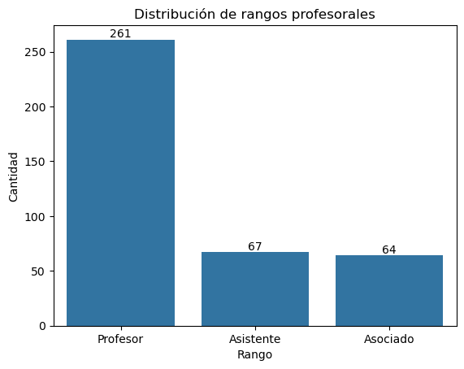

```python
grafico = sns.countplot(data=df, x='Rango')

for p in grafico.patches:
    grafico.annotate(
        f'{int(p.get_height())}',
        (p.get_x() + p.get_width() / 2, p.get_height()),
        ha='center',
        va='bottom'
    )

plt.ylabel('Cantidad')
plt.title("Distribución de rangos profesorales")
plt.show()
```

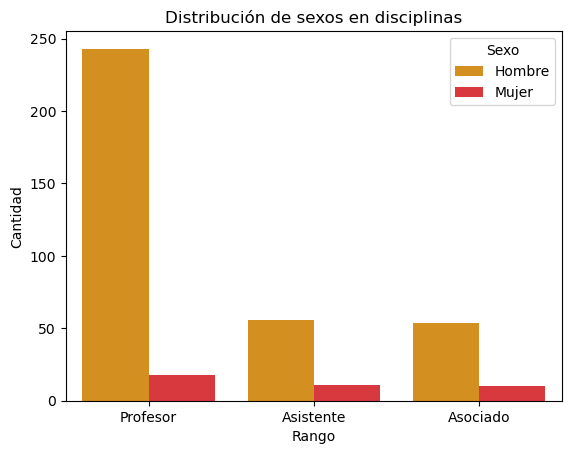

```python
sns.countplot(data=df, x='Rango', hue='Sexo', palette=map_color_sexo)

plt.title('Distribución de sexos en disciplinas')
plt.ylabel('Cantidad')
plt.show()
```

#### El rango de profesor es el dominante en la universidad, mantieniendo un balance entre el rango de asistente y asociado. Sin embargo, es claro que la cantidad de hombre en el data set es mucho mayor. Además, se debe tener en cuenta que la mayoría de esos hombres tienen rango de profesor, que está asociado a mayores salarios.

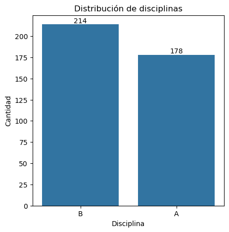

```python
plt.figure(figsize=(5,5))
grafico = sns.countplot(data=df, x='Disciplina')

for barra in grafico.patches:
    grafico.annotate(
    f'{int(barra.get_height())}',
    (barra.get_x() + barra.get_width()/2 , barra.get_height()),
    ha='center',
    va='bottom')

plt.title('Distribución de disciplinas')
plt.ylabel('Cantidad')
plt.show()
```

## 2.1. Salario por rango

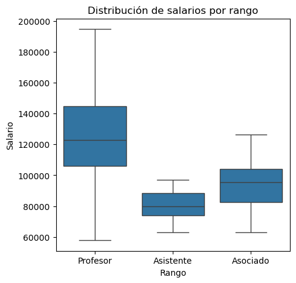

```python
plt.figure(figsize=(5,5))
sns.boxplot(data=df, x='Rango', y='Salario')
plt.title('Distribución de salarios por rango')

plt.show()
```

#### Al realizar este gráfico, se puede observar que los rango no parecen seguir el orden natural, bien sea decreciente o creciente. Por tanto, se realiza una asignación de orden, algo análogo a convertir la columna en factor para R.

```python
orden_rangos = ['Asistente', 'Asociado', 'Profesor']

df['Rango'] = pd.Categorical(df['Rango'], categories=orden_rangos) # ordered=True
```

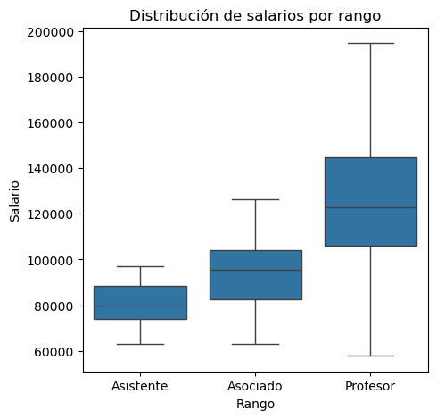

```python
plt.figure(figsize=(5,5))
sns.boxplot(data=df, x='Rango', y='Salario')

plt.title('Distribución de salarios por rango')
plt.show()
```

## 2.2. Salario por disciplina

```python
orden_disciplinas = ['A', 'B']

df['Disciplina'] = pd.Categorical(df['Disciplina'], categories=orden_disciplinas) # ordered=True
```

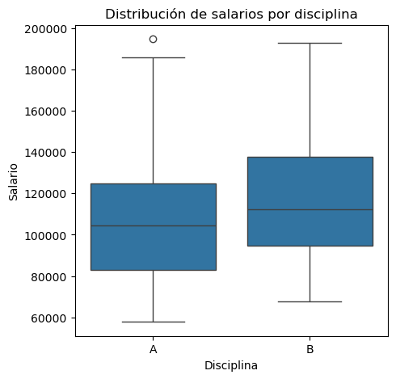

```python
plt.figure(figsize=(5,5))
sns.boxplot(data=df, x='Disciplina', y='Salario')

plt.title('Distribución de salarios por disciplina')
plt.show()
```

## 2.3. Salario vs rango por sexo

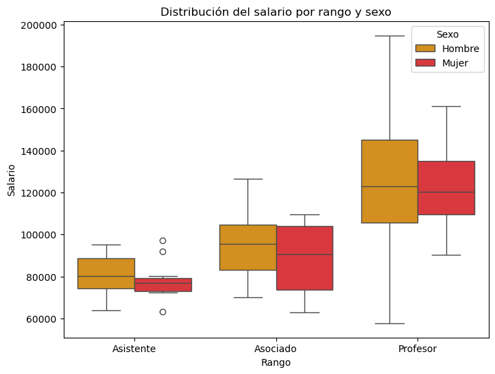

```python
plt.figure(figsize=(8,6))

sns.boxplot(
    data=df,
    x='Rango',
    y='Salario',
    hue='Sexo', # subdivide la categoría en x
    palette=map_color_sexo,
    width=0.8
)

plt.title("Distribución del salario por rango y sexo")
plt.show()
```

#### En este gráfico se observa que el salario de hombres por rango profesoral es más alto, la mediana siempre está por encima del salario mediano de las mujeres.

## 2.4. Salario vs disciplina por sexo

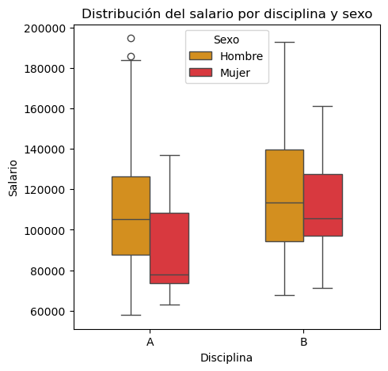

```python
plt.figure(figsize=(5,5))
sns.boxplot(data=df, x='Disciplina', y='Salario',
           hue='Sexo', palette=map_color_sexo, width=0.5)
plt.title('Distribución del salario por disciplina y sexo')

plt.show()
```

#### Nuevamente, el salario mediano de los hombres en ambas disciplinas es mayor al de las mujeres. Sin embargo, el salario de hombres presenta una mayor dispersión.

```python
df.head(2)
```

|  | Rango | Disciplina | Años_desde_Phd | Años_servicio | Sexo | Salario |
| --- | --- | --- | --- | --- | --- | --- |
| 0 | Profesor | B | 19.5 | 18 | Hombre | 139750 |
| 1 | Profesor | B | 20.0 | 16 | Hombre | 173200 |

## 2.5. Salario por Años desde Phd

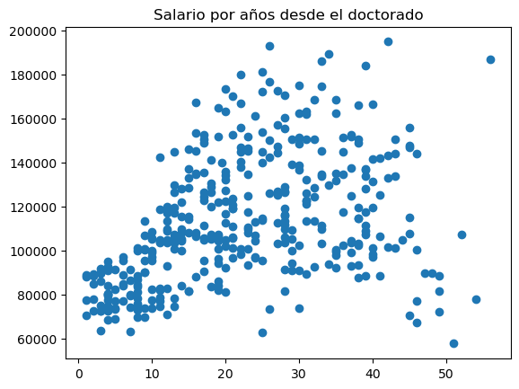

```python
plt.scatter(df['Años_desde_Phd'], df['Salario'])

plt.title('Salario por años desde el doctorado')
plt.show()
```

#### Se pretende revisar una posible desigualdad salarial explicada por el sexo, por tanto, se procede a dividir por sexo.

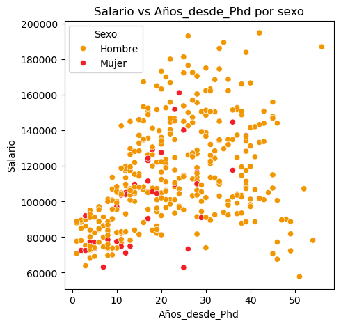

```python
plt.figure(figsize=(5,5))

sns.scatterplot(data=df, x='Años_desde_Phd', y='Salario', hue='Sexo', palette=map_color_sexo)

plt.title('Salario vs Años_desde_Phd por sexo')
plt.show()
```

#### Por la cantidad de dispersión, no es concluyente el gráfico presentado.

## 2.6. Salario por años de servicio

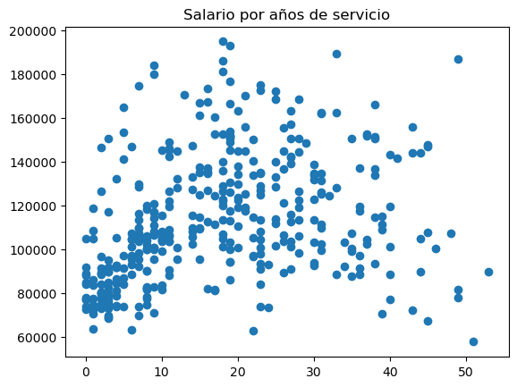

```python
plt.scatter(df['Años_servicio'], df['Salario'])


plt.title('Salario por años de servicio')
plt.show()
```

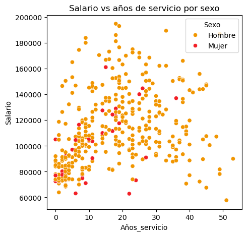

```python
plt.figure(figsize=(5,5))

sns.scatterplot(data=df, x='Años_servicio', y='Salario', hue='Sexo', palette=map_color_sexo)

plt.title('Salario vs años de servicio por sexo')
plt.show()
```

```python
df.head(2)
```

|  | Rango | Disciplina | Años_desde_Phd | Años_servicio | Sexo | Salario |
| --- | --- | --- | --- | --- | --- | --- |
| 0 | Profesor | B | 19.5 | 18 | Hombre | 139750 |
| 1 | Profesor | B | 20.0 | 16 | Hombre | 173200 |

# 3. Árbol de decisión como regresor

#### Un árbol de decisión es un modelo de aprendizaje automático que permite predecir el valor de una variable objetivo a partir de un conjunto de variables explicativas mediante una serie de particiones sucesivas del conjunto de datos. Cuando se utiliza para predecir valores numéricos, como el salario, se habla de árboles de decisión de regresión, los cuales dividen los datos en subconjuntos cada vez más homogéneos con respecto a la variable de interés. Cada división del árbol se realiza seleccionando la variable y el punto de corte que mejor separan los datos según un criterio de optimización.

#### La lógica que guía estas divisiones se relaciona con principios de la Teoría de la Información propuesta por Claude Shannon. En particular, muchos algoritmos de árboles de decisión utilizan medidas como la entropía o la reducción de impureza para evaluar qué tan informativa es una partición. La entropía mide el grado de incertidumbre presente en un conjunto de datos; por lo tanto, una buena división es aquella que reduce dicha incertidumbre y produce subconjuntos más homogéneos. De esta forma, el árbol va organizando la información de manera jerárquica hasta llegar a predicciones cada vez más precisas.

```python
import statistics as statis

from sklearn.linear_model import LinearRegression
from sklearn.model_selection import train_test_split, cross_validate, cross_val_predict, KFold, cross_val_score
from sklearn.metrics import mean_squared_error, r2_score, mean_absolute_error
from sklearn.tree import DecisionTreeRegressor
from sklearn.pipeline import Pipeline
```

```python
df.head(2)
```

|  | Rango | Disciplina | Años_desde_Phd | Años_servicio | Sexo | Salario |
| --- | --- | --- | --- | --- | --- | --- |
| 0 | Profesor | B | 19.5 | 18 | Hombre | 139750 |
| 1 | Profesor | B | 20.0 | 16 | Hombre | 173200 |

#### El árbol de decisión necesita que las variables estén en formato numérico, al menos como etiqueta. Por tanto, se crea una copia del dataset original llamada `df_edit` para realizar la conversión de cada variable categórica a numérica.

```python
df_edit = df.copy()

df_edit['Rango'] = df_edit['Rango'].cat.rename_categories({'Asistente': 0, 'Asociado': 1, 'Profesor': 2})

df_edit['Disciplina'] = df_edit['Disciplina'].cat.rename_categories({'A': 0, 'B': 1})

df_edit['Sexo'] = df_edit['Sexo'].astype('category')
df_edit['Sexo'] = df_edit['Sexo'].cat.rename_categories({'Hombre': 0, 'Mujer': 1})

df_edit.head(2)
```

|  | Rango | Disciplina | Años_desde_Phd | Años_servicio | Sexo | Salario |
| --- | --- | --- | --- | --- | --- | --- |
| 0 | 2 | 1 | 19.5 | 18 | 0 | 139750 |
| 1 | 2 | 1 | 20.0 | 16 | 0 | 173200 |

```python
X = df_edit[['Rango','Disciplina', 'Años_desde_Phd', 'Años_servicio', 'Sexo']]
y = df_edit['Salario']
```

```python
modelo = DecisionTreeRegressor(
    max_depth=6,          # controla complejidad
    min_samples_split=10, # evita divisiones muy pequeñas
    min_samples_leaf=5,   # tamaño mínimo por hoja
    random_state=42       # reproducibilidad
)

kfold = KFold(
    n_splits=5,
    shuffle=True, # Evita que se tomen los folds en orden, lo hace aleatorio
    random_state=21
)

scores = cross_val_score(
    modelo, X, y,
    cv=kfold,
    scoring="neg_root_mean_squared_error"
) # Aquí el .fit ocurre internamente

rmse_scores = -scores  # porque sklearn devuelve negativo
print("RMSE por fold:", rmse_scores)
print("RMSE promedio:", rmse_scores.mean())
```

```
RMSE por fold: [22264.00238546 23927.04068031 20889.96684863 19366.0872566
 24054.46923088]
RMSE promedio: 22100.313280378417
```

```python
modelo.fit(X, y)
```

```
DecisionTreeRegressor(max_depth=6, min_samples_leaf=5, min_samples_split=10,
                      random_state=42)
```

```python
valor_predicho = modelo.predict(X)
```

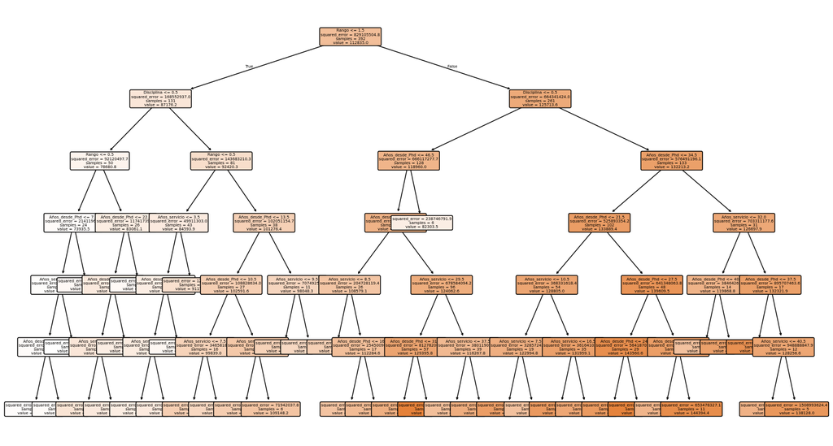

```python
#from sklearn import plot_tree
from sklearn.tree import plot_tree
# Graficar el árbol
plt.figure(figsize=(18, 10))
plot_tree(
    modelo,
    feature_names= X.columns,
    filled=True,
    rounded=True,
    precision = 1,
    fontsize=5
)
plt.show()
```

#### Este árbol de decisión no considera la variable Sexo como influyente, sin embargo, esto no es un argumento válido para descartar la posibilidad, solo es útil como exploración y es más eficiente para verificar que para negar.

```python
import statsmodels.formula.api as smf

modelo = smf.ols('Salario ~ Sexo + Disciplina', data=df_edit).fit()

print(modelo.summary())
```

```
                            OLS Regression Results
==============================================================================
Dep. Variable:                Salario   R-squared:                       0.045
Model:                            OLS   Adj. R-squared:                  0.041
Method:                 Least Squares   F-statistic:                     9.261
Date:                Sat, 14 Mar 2026   Prob (F-statistic):           0.000118
Time:                        18:37:36   Log-Likelihood:                -4572.1
No. Observations:                 392   AIC:                             9150.
Df Residuals:                     389   BIC:                             9162.
Df Model:                           2
Covariance Type:            nonrobust
===================================================================================
                      coef    std err          t      P>|t|      [0.025      0.975]
-----------------------------------------------------------------------------------
Intercept         1.09e+05   2170.876     50.195      0.000    1.05e+05    1.13e+05
Sexo[T.1]       -1.306e+04   4765.419     -2.741      0.006   -2.24e+04   -3692.300
Disciplina[T.1]  9466.6603   2864.863      3.304      0.001    3834.108    1.51e+04
==============================================================================
Omnibus:                       21.414   Durbin-Watson:                   1.989
Prob(Omnibus):                  0.000   Jarque-Bera (JB):               22.977
Skew:                           0.569   Prob(JB):                     1.02e-05
Kurtosis:                       2.663   Cond. No.                         3.94
==============================================================================

Notes:
[1] Standard Errors assume that the covariance matrix of the errors is correctly specified.
```

# 4. Conclusiones

#### En conjunto, los resultados indican que si bien la disciplina desempeña un papel importante en la determinación de los salarios, el sexo continúa siendo un factor relevante en la explicación de las diferencias salariales observadas. Este hallazgo resalta la importancia de realizar análisis desagregados y de controlar por variables estructurales en el estudio de desigualdades salariales, evitando interpretaciones simplistas basadas únicamente en promedios agregados, las cuales pueden verse afectadas por fenómenos estadísticos como la Paradoja de Simpson.